# Case-based Introduction to Healthcare Analytics with R

22 July 2014

## INFERENTIAL STATISTICS

## Expectation Management

This is **not** a graduate-level math / stats class.

[figure not shown]

Image source: http://goo.gl/y3S05T

## Expectation Management

A journey of a thousand miles begins with the **first** step. There are some very basic inferential stats to get you started **comfortably** with R.

[figure not shown]

Image source: http://goo.gl/DGwVxp

## Expectation Management

I am a [casual user](http://www.urbandictionary.com/define.php?term=Casual+User) of R. If I can do it, you **can** do it too!

So, ask Vik (hello, Stats PhD) about anything you don't understand today ;)

[figure not shown]

Image source: http://goo.gl/OPztxu

## Load R Packages and FHS Dataset

The following R packages are useful **in and beyond** this workshop.

```r
library(dplyr)
library(ggplot2)
library(reshape2)
library(psych)
```

R works with CSV and [many other](http://cran.r-project.org/doc/manuals/r-release/R-data.html) data formats.

```r
fhs <- read.csv("frmgham2.csv")
```

The following converts column names to upper case for ease of reference to the [FHS data documentation](https://biolincc.nhlbi.nih.gov/static/studies/teaching/framdoc.pdf). However, such a conversion is generally neither necessary nor recommended. Instead, cultivate **good R habits** by learning from [Google's R Style Guide](https://google-styleguide.googlecode.com/svn/trunk/Rguide.xml).

```r
colnames(fhs) <- toupper(colnames(fhs))
```

## Task 1: Hypothsis Testing for a Single Sample

[figure not shown]

We wish to know whether the mean heart rate of "healthy" people at exam 1 is equal to 70 beats per minute (bpm). The criteria for "healthy" will be discussed soon.

## Task 1: Hypothsis Testing for a Single Sample

### — But first, understand your data (with summary stats)

```r
with(fhs, summary(HEARTRTE)) # summary(fhs$HEARTRTE)
```

```
##    Min. 1st Qu.  Median    Mean 3rd Qu.    Max.    NA's
##    37.0    69.0    75.0    76.8    85.0   220.0       6
```

To get other summary stats, use `length(HEARTRTE)`, `sd(HEARTRTE)`, `range(HEARTRTE)`, etc. Or try the following "shortcut".

```r
with(fhs, describe(HEARTRTE))
```

```
##   vars     n  mean    sd median trimmed   mad min max range skew kurtosis
## 1    1 11621 76.78 12.46     75   76.15 10.38  37 220   183 0.68     2.08
##     se
## 1 0.12
```

## Task 1: Hypothsis Testing for a Single Sample

### — But first, understand your data (with graphs)

```
## stat_bin: binwidth defaulted to range/30. Use 'binwidth = x' to adjust this.
```

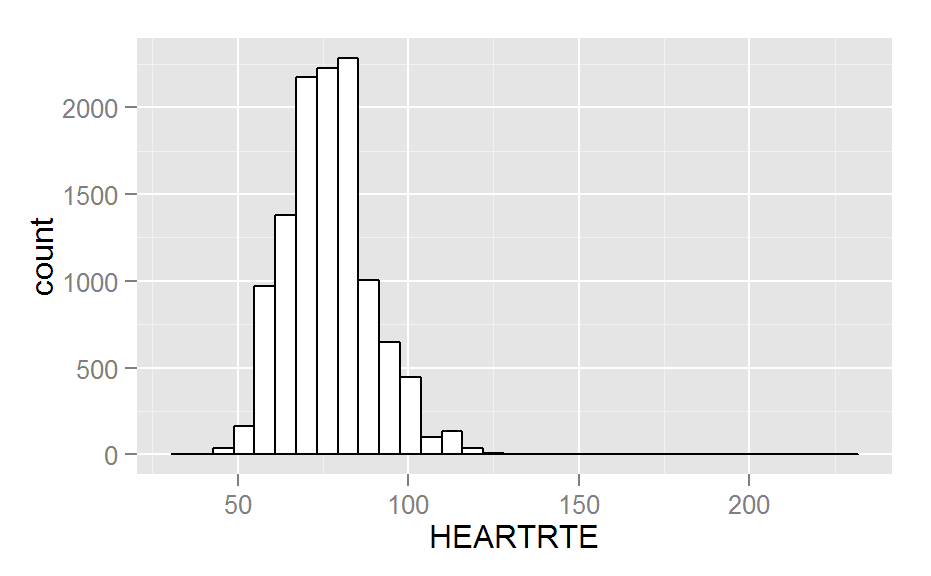

```r
ggplot(fhs, aes(HEARTRTE)) +
  geom_histogram(color = "black", fill = "white")
```

## Task 1: Hypothsis Testing for a Single Sample

### — But first, understand your data (with graphs)

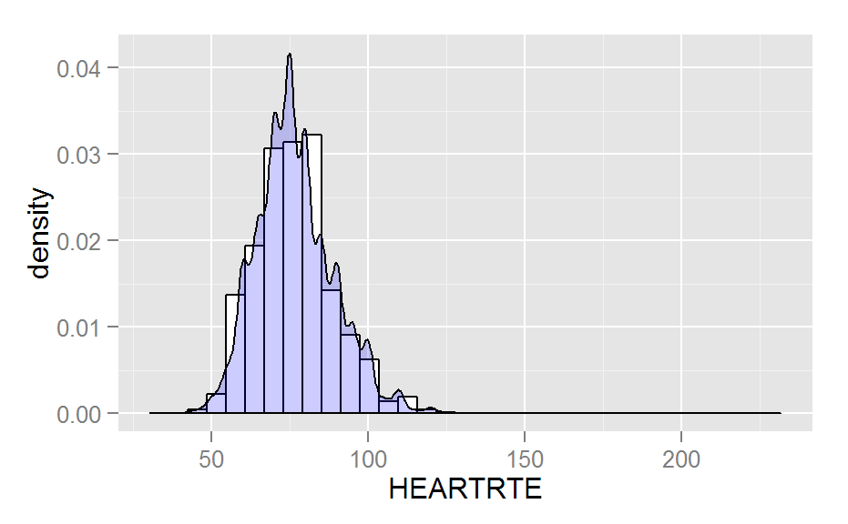

```r
ggplot(fhs, aes(x = HEARTRTE, y = ..density..)) +
  geom_histogram(color = "black", fill = "white") +
  geom_density(fill = "blue", alpha = 0.2)
```

## Task 1: Hypothsis Testing for a Single Sample

### — Let's take a "healthy" group at exam 1

```r
fhs.healthy <- filter(fhs, PERIOD == 1 & CURSMOKE == 0 & BMI < 25 & DIABP < 80
                      & SYSBP < 120 & DIABETES == 0)

with(fhs.healthy, describe(HEARTRTE))
```

[output not shown]

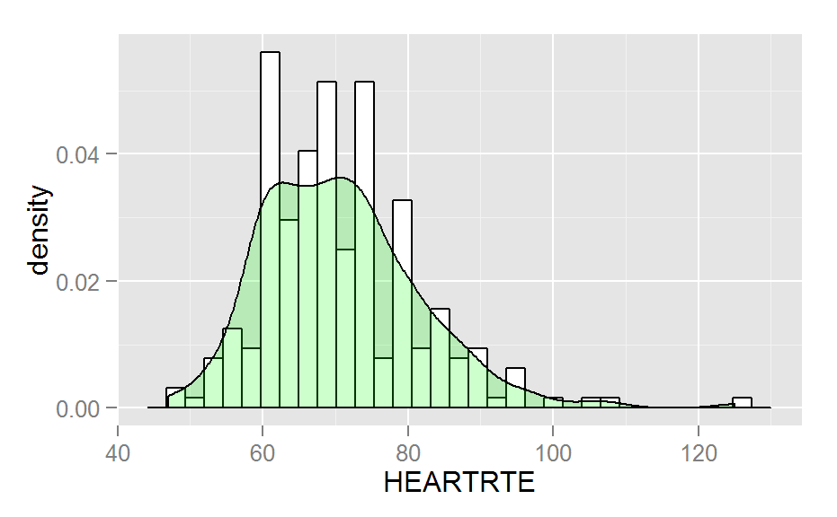

```r
ggplot(fhs.healthy, aes(x = HEARTRTE, y = ..density..)) +
  geom_histogram(color = "black", fill = "white") +
  geom_density(fill = "green", alpha = 0.2)
```

## Task 1: Hypothsis Testing for a Single Sample

### — [One-sample *t*-test](http://en.wikipedia.org/wiki/Student%27s_t-test#One-sample_t-test)

We wish to know whether the mean heart rate of "healthy" people at exam 1 is equal to 70 bpm. [Null hypothesis](http://en.wikipedia.org/wiki/Null_hypothesis), \(H_0: \mu = 70\). [Alternative hypothesis](http://en.wikipedia.org/wiki/Alternative_hypothesis), \(H_1: \mu \neq 70\). We test the null hypothesis with a **one-sample *t*-test** at a [significance level](http://en.wikipedia.org/wiki/Statistical_significance) (\(\alpha\)) of 0.05.

```r
with(fhs.healthy, t.test(HEARTRTE, mu = 70))
```

```
##
##  One Sample t-test
##
## data:  HEARTRTE
## t = 0.999, df = 246, p-value = 0.3188
## alternative hypothesis: true mean is not equal to 70
## 95 percent confidence interval:
##  69.32 72.08
## sample estimates:
## mean of x
##      70.7
```

**Interpretation**: Since \(p > 0.05\), we fail to reject \(H_0\) at \(\alpha = 0.05\). Therefore there is insufficient evidence to suggest that the mean heart rate of "healthy" people at exam 1 is statistically significantly different from 70 bpm.

## About Null Hypothsis ;)

"Hell, my eighth grade science class managed to conclusively reject it just based on a classroom experiment. It's pretty sad to hear about million-dollar research teams who can't even manage that."

## Task 2: Hypothsis Testing (HT) for 2 Samples

[figure not shown]

Task 2a: We wish to know whether there is a difference in mean heart rates between exam 1 and exam 2.

Task 2b: We wish to know whether there is a difference in mean heart rates between men and women at exam 1.

## Task 2a: HT for 2 Samples, Paired Comparisons

### — But first, reshape and understand your data

Reshape heart rate data from **long** format to **wide** format.

```r
fhs.wide <- dcast(fhs, RANDID + SEX ~ PERIOD, value.var = "HEARTRTE")

colnames(fhs.wide)[3:5] <- c("HEARTRTE1", "HEARTRTE2", "HEARTRTE3")

tbl_df(fhs.wide)
```

```
## Source: local data frame [4,434 x 5]
##
##    RANDID SEX HEARTRTE1 HEARTRTE2 HEARTRTE3
## 1    2448   1        80        NA        69
## 2    6238   2        95        80        80
## 3    9428   1        75        75        NA
## 4   10552   2        65        60        NA
## 5   11252   2        85        90        74
## 6   11263   2        77       120        86
## 7   12629   2        60        80        NA
## 8   12806   2        79        75        75
## 9   14367   1        76        85        92
## 10  16365   1        93        75        75
## ..    ... ...       ...       ...       ...
```

## Task 2a: HT for 2 Samples, Paired Comparisons

### — But first, reshape and understand your data

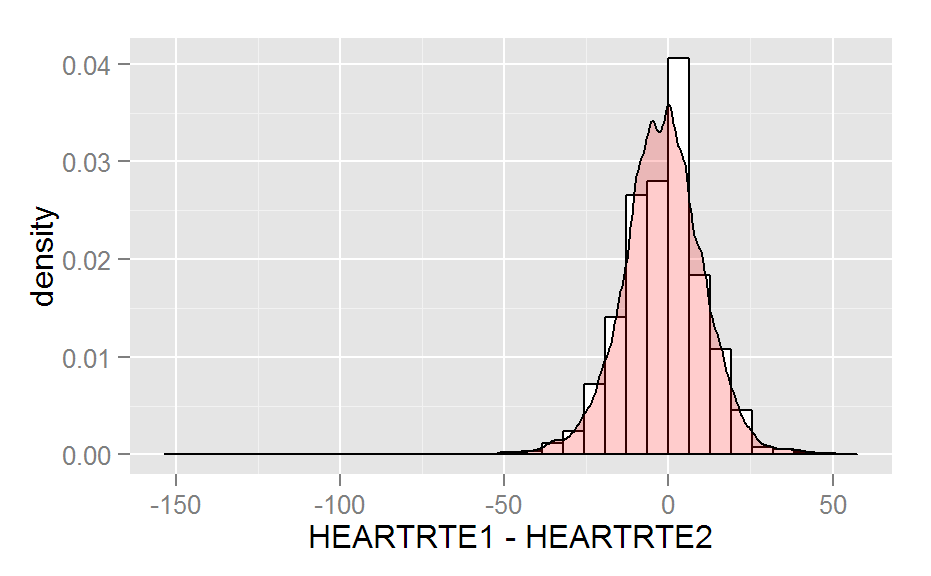

```r
ggplot(fhs.wide, aes(x = HEARTRTE1 - HEARTRTE2, y = ..density..)) +
  geom_histogram(color = "black", fill = "white") +
  geom_density(fill = "red", alpha = 0.2)
```

## Task 2a: HT for 2 Samples, Paired Comparisons

### — [Paired *t*-test](http://en.wikipedia.org/wiki/Student%27s_t-test#Dependent_t-test_for_paired_samples)

We wish to know whether there is a difference in mean heart rates between exam 1 and exam 2. \(H_0: \mu_d = 0\). \(H_1: \mu_d \neq 0\). We test the null hypothesis with a **paired *t*-test** at \(\alpha = 0.05\).

```r
with(fhs.wide, t.test(HEARTRTE1, HEARTRTE2, paired = TRUE))
```

```
##
##  Paired t-test
##
## data:  HEARTRTE1 and HEARTRTE2
## t = -8.951, df = 3927, p-value < 2.2e-16
## alternative hypothesis: true difference in means is not equal to 0
## 95 percent confidence interval:
##  -2.158 -1.383
## sample estimates:
## mean of the differences
##                  -1.771
```

**Interpretation**: Since \(p < 0.05\), we reject \(H_0\) at \(\alpha = 0.05\). Therefore there is a statistically significant difference in mean heart rates between exam 1 and exam 2.

## Task 2a: HT for 2 Samples, Paired Comparisons

### — Statistical signficance vs clinical signficance

```r
set.seed(12345)
fhs.asample <- sample_n(fhs.wide, 200)
```

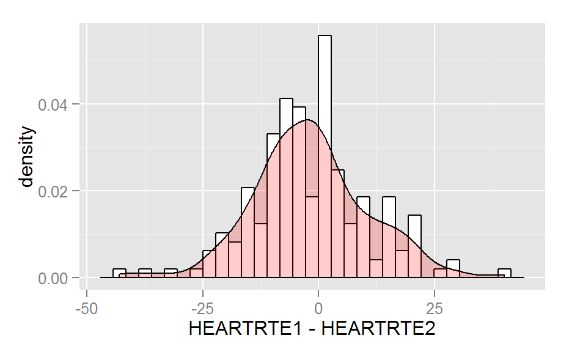

```r
ggplot(fhs.asample, aes(x = HEARTRTE1 - HEARTRTE2, y = ..density..)) +
  geom_histogram(color = "black", fill = "white") +
  geom_density(fill = "red", alpha = 0.2)
```

## Task 2a: HT for 2 Samples, Paired Comparisons

### — Statistical signficance vs clinical signficance

```r
with(fhs.asample, t.test(HEARTRTE1, HEARTRTE2, paired = TRUE))
```

```
##
##  Paired t-test
##
## data:  HEARTRTE1 and HEARTRTE2
## t = -1.933, df = 174, p-value = 0.05487
## alternative hypothesis: true difference in means is not equal to 0
## 95 percent confidence interval:
##  -3.68418  0.03847
## sample estimates:
## mean of the differences
##                  -1.823
```

Be careful when interpreting the results from hypothesis testing **if the sample size is large**, because any small departure from the hypothesized value will probably be detected, even when the difference is of little or no clinical significance.

## About *p*-value ;)

Overcome the slavish obsession for the *p*-value.

[figure not shown]

Image source: http://goo.gl/RvuLlx

## Task 2b: HT for 2 Samples, Unpaired Compar.

### — But first, understand your data

We wish to know whether there is a difference in mean heart rates between men and women at exam 1.

```r
with(fhs.wide, describeBy(HEARTRTE1, group = SEX))
```

```
## group: 1
##   vars    n mean   sd median trimmed   mad min max range skew kurtosis
## 1    1 1943 74.4 11.9     75   73.75 11.86  44 130    86 0.58     0.63
##     se
## 1 0.27
## --------------------------------------------------------
## group: 2
##   vars    n  mean    sd median trimmed   mad min max range skew kurtosis
## 1    1 2490 77.06 12.15     75   76.34 10.38  46 143    97  0.7     1.07
##     se
## 1 0.24
```

## Task 2b: HT for 2 Samples, Unpaired Compar.

### — But first, understand your data

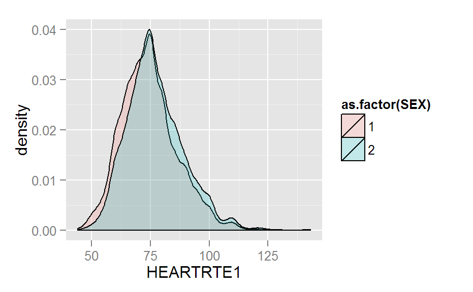

```r
ggplot(fhs.wide, aes(HEARTRTE1, fill = as.factor(SEX))) +
  geom_density(alpha = 0.2)
```

## Task 2b: HT for 2 Samples: Unpaired Compar.

### — [Independent two-sample *t*-test](http://en.wikipedia.org/wiki/Student%27s_t-test#Independent_two-sample_t-test)

We wish to know whether there is a difference in mean heart rates between men and women at exam 1. \(H_0: \mu_1 - \mu_2 = 0\). \(H_1: \mu_1 - \mu_2 \neq 0\). We test the null hypothesis with **independent two-sample *t*-tests** at \(\alpha = 0.05\).

Assuming equal population variances, \(\sigma^2_1 = \sigma^2_2\), the following test generates \(p < 0.05\).

```r
t.test(HEARTRTE1 ~ SEX, data = fhs.wide, var.equal = TRUE)
```

Assuming unequal population variances, \(\sigma^2_1 \neq \sigma^2_2\), the following test generates \(p < 0.05\).

```r
t.test(HEARTRTE1 ~ SEX, data = fhs.wide)
```

However, the following tests both generate \(p > 0.05\). Why?

```r
t.test(HEARTRTE1 ~ SEX, data = fhs.asample, var.equal = TRUE)
t.test(HEARTRTE1 ~ SEX, data = fhs.asample)
```

## Task 3: Hypothsis Testing for \(\geq\) 3 Samples

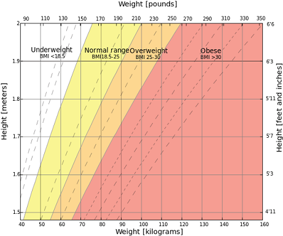

Task 3a: We wish to know whether there is a difference in mean body mass indices (BMIs) among people with different education levels at exam 1.

Task 3b: If there were a difference, we wish to know which education levels differ from one another.

## Task 3a: HT for \(\geq\) 3 Samples

### — But first, understand your data

```r
with(filter(fhs, PERIOD == 1), describeBy(BMI, group = EDUC))
```

```
## group: 1
##   vars    n  mean   sd median trimmed  mad   min  max range skew kurtosis
## 1    1 1815 26.62 4.48  26.25   26.29 3.83 15.54 56.8 41.26 1.05     2.84
##     se
## 1 0.11
## --------------------------------------------------------
## group: 2
##   vars    n  mean   sd median trimmed  mad   min   max range skew kurtosis
## 1    1 1274 25.34 3.86  24.88    25.1 3.55 15.96 45.79 29.83 0.77     1.43
##     se
## 1 0.11
## --------------------------------------------------------
## group: 3
##   vars   n  mean   sd median trimmed  mad   min  max range skew kurtosis
## 1    1 714 25.01 3.44  24.62   24.81 3.14 16.73 39.6 22.87  0.6     0.56
##     se
## 1 0.13
## --------------------------------------------------------
## group: 4
##   vars   n  mean   sd median trimmed  mad   min   max range skew kurtosis
## 1    1 500 25.29 3.58  24.98   25.11 3.14 16.59 40.58 23.99 0.82     1.99
##     se
## 1 0.16
```

## Task 3a: HT for \(\geq\) 3 Samples

### — But first, understand your data

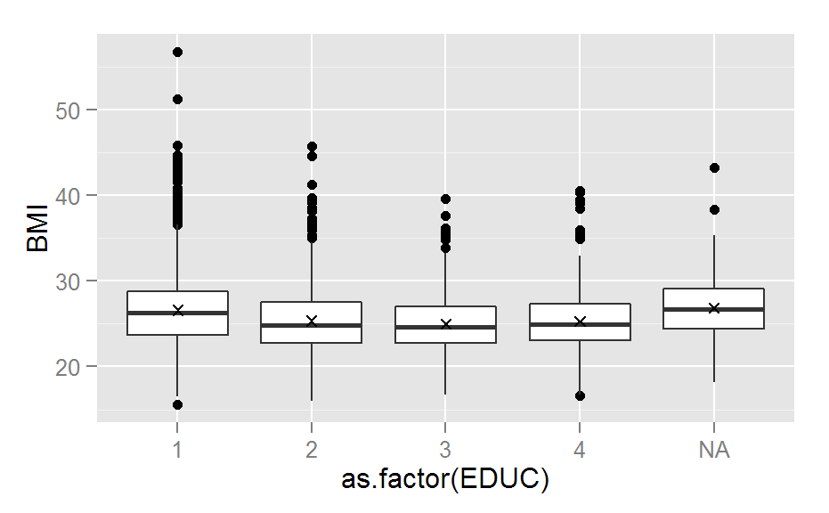

```r
ggplot(filter(fhs, PERIOD == 1), aes(x = as.factor(EDUC), y = BMI)) +
  geom_boxplot() +
  stat_summary(fun.y = "mean", geom = "point", shape = 4)
```

## Task 3a: HT for \(\geq\) 3 Samples

### — [One-way ANOVA *F*-test](http://en.wikipedia.org/wiki/One-way_analysis_of_variance#The_hypothesis_test)

We wish to know whether there is a difference in mean BMIs among people with different education levels at exam 1. \(H_0: \mu_1 = \mu_2 = \mu_3 = \mu_4\). \(H_1:\) otherwise. We test the null hypothesis with a **one-way ANOVA (analysis of variance) *F*-test** at \(\alpha = 0.05\).

```r
summary(aov(BMI ~ as.factor(EDUC), data = filter(fhs, PERIOD == 1)))
```

```
##                   Df Sum Sq Mean Sq F value Pr(>F)
## as.factor(EDUC)    3   2064     688    42.1 <2e-16 ***
## Residuals       4299  70255      16
## ---
## Signif. codes:  0 '***' 0.001 '**' 0.01 '*' 0.05 '.' 0.1 ' ' 1
## 131 observations deleted due to missingness
```

**Interpretation**: Since \(p < 0.05\), we reject \(H_0\) at \(\alpha = 0.05\). Therefore there is a statistically significant difference in mean BMIs among people with different education levels at exam 1.

However, is the conclusion **good enough**?

## Task 3b: HT for \(\geq\) 3 Samples: Post-hoc Analysis

### — [Tukey's HSD test](http://en.wikipedia.org/wiki/Tukey%27s_range_test)

```r
TukeyHSD(aov(BMI ~ as.factor(EDUC), data = filter(fhs, PERIOD == 1)))
```

```
##   Tukey multiple comparisons of means
##     95% family-wise confidence level
##
## Fit: aov(formula = BMI ~ as.factor(EDUC), data = filter(fhs, PERIOD == 1))
##
## $`as.factor(EDUC)`
##         diff     lwr     upr  p adj
## 2-1 -1.27807 -1.6578 -0.8983 0.0000
## 3-1 -1.61246 -2.0714 -1.1535 0.0000
## 4-1 -1.32931 -1.8541 -0.8046 0.0000
## 3-2 -0.33438 -0.8201  0.1513 0.2883
## 4-2 -0.05124 -0.5995  0.4970 0.9951
## 4-3  0.28314 -0.3227  0.8890 0.6262
```

**Interpretation**: What can you conclude based on your learning from Task 2?

## AS A (HEALTH) DATA SCIENTIST

## You Should Be Good at This

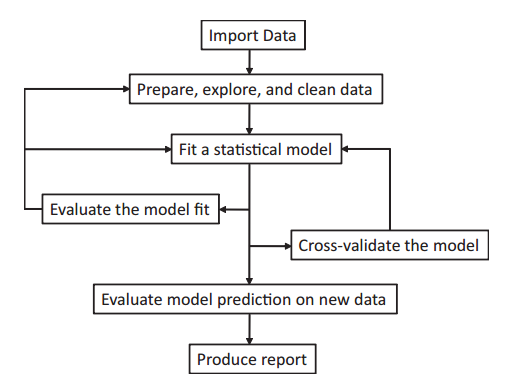

Image source: http://goo.gl/g2mIR3

## You Should Be Better at This

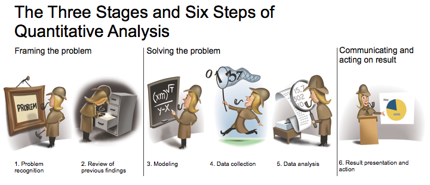

Image source: http://goo.gl/7ySzDw